# Fake Pramipexole Trial Simulation

```r
library(dplyr)
library(tidyr)
library(ggplot2)
library(lme4)
library(lmerTest)
library(emmeans)
library(broom.mixed)
library(knitr)

set.seed(20260311)
```

## Goal

This Quarto document generates a **fully fictitious dataset** inspired by the design and the main orders of magnitude reported in `article.pdf`.

Important points:

- These are **not the real trial data**
- The simulated sample size follows your request: **75 patients in the pramipexole arm and 70 in the placebo arm**
- The real article used a **1:1 randomisation** and had **75 vs 75 eligible randomised participants**
- The analysis below is only an **illustration** of a plausible mixed-model workflow close to the published primary analysis

## Simulation assumptions

The fake data are loosely based on the paper:

- mean baseline QIDS-SR16 around **16.3**
- age around **44.9 years**
- about **56% women**
- 9 sites with a distribution roughly inspired by the published table
- a stronger reduction in QIDS-SR16 in the pramipexole arm by week 12
- gradual increase in missing data over follow-up

## 1. Simulate participant-level baseline data

```r
sites <- c(
  "Oxford", "Newcastle", "Liverpool", "King's College London",
  "Bristol", "UCL", "Nottingham", "Midlands Partnership", "Pennine Care"
)

site_probs <- c(74, 26, 12, 12, 10, 6, 6, 3, 1)
site_probs <- site_probs / sum(site_probs)

n_prami <- 75
n_placebo <- 70
n_total <- n_prami + n_placebo

draw_qids_baseline <- function(severity_cat) {
  if (severity_cat == "11-15") {
    x <- rnorm(1, mean = 13.5, sd = 1.2)
    return(min(max(x, 11), 15))
  }
  if (severity_cat == "16-20") {
    x <- rnorm(1, mean = 17.6, sd = 1.2)
    return(min(max(x, 16), 20))
  }
  x <- rnorm(1, mean = 22.0, sd = 1.3)
  min(max(x, 20.1), 25)
}

participants <- tibble(
  id = 1:n_total,
  site = sample(sites, size = n_total, replace = TRUE, prob = site_probs),
  age = pmin(pmax(rnorm(n_total, mean = 44.9, sd = 14), 18), 74),
  sex = sample(c("Female", "Male"), size = n_total, replace = TRUE, prob = c(0.56, 0.44)),
  severity_cat = sample(
    c("11-15", "16-20", ">20"),
    size = n_total,
    replace = TRUE,
    prob = c(0.45, 0.43, 0.12)
  )
) |>
  mutate(
    age_group = if_else(age <= 50, "18-50", ">50"),
    baseline_qids = vapply(severity_cat, draw_qids_baseline, numeric(1))
  ) |>
  slice_sample(prop = 1) |>
  mutate(entry_order = row_number())

kable(head(participants, 10), digits = 2, caption = "First 10 fictitious participants")
```

First 10 fictitious participants

| id | site | age | sex | severity_cat | age_group | baseline_qids | entry_order |
| --- | --- | --- | --- | --- | --- | --- | --- |
| 131 | UCL | 37.07 | Male | 16-20 | 18-50 | 19.66 | 1 |
| 124 | Oxford | 44.56 | Female | 11-15 | 18-50 | 12.57 | 2 |
| 51 | Liverpool | 38.44 | Male | 16-20 | 18-50 | 18.53 | 3 |
| 82 | Oxford | 58.54 | Male | 16-20 | >50 | 16.00 | 4 |
| 130 | Oxford | 60.64 | Female | >20 | >50 | 22.95 | 5 |
| 46 | Newcastle | 18.84 | Female | >20 | 18-50 | 20.10 | 6 |
| 8 | Oxford | 61.14 | Female | 16-20 | >50 | 16.98 | 7 |
| 39 | Oxford | 49.81 | Female | 16-20 | 18-50 | 16.37 | 8 |
| 133 | Oxford | 40.30 | Female | 11-15 | 18-50 | 13.47 | 9 |
| 110 | Oxford | 39.70 | Male | 11-15 | 18-50 | 15.00 | 10 |

## 2. Assign treatment with a minimisation algorithm

This section mimics the published randomisation logic:

- first 10 participants: random allocation without minimisation
- then a minimisation algorithm
- 80% probability in favour of the allocation that minimises imbalance

To match your request, the fake dataset is capped at **75 pramipexole** and **70 placebo**.

```r
imbalance_score <- function(df) {
  score_vars <- c("site", "age_group", "sex", "severity_cat")
  total_score <- 0

  for (v in score_vars) {
    tab <- table(df[[v]], df$treatment)
    for (arm in c("Placebo", "Pramipexole")) {
      if (!arm %in% colnames(tab)) {
        tab <- cbind(tab, setNames(rep(0, nrow(tab)), arm))
      }
    }
    tab <- tab[, c("Placebo", "Pramipexole"), drop = FALSE]
    total_score <- total_score + sum(abs(tab[, "Placebo"] - tab[, "Pramipexole"]))
  }

  total_score
}

assignments <- participants
assignments$treatment <- NA_character_

for (i in seq_len(n_total)) {
  current <- assignments[seq_len(i - 1), , drop = FALSE]
  remaining_prami <- n_prami - sum(current$treatment == "Pramipexole", na.rm = TRUE)
  remaining_placebo <- n_placebo - sum(current$treatment == "Placebo", na.rm = TRUE)

  if (remaining_prami == 0) {
    assignments$treatment[i] <- "Placebo"
    next
  }
  if (remaining_placebo == 0) {
    assignments$treatment[i] <- "Pramipexole"
    next
  }

  if (i <= 10) {
    assignments$treatment[i] <- sample(c("Placebo", "Pramipexole"), size = 1)
    next
  }

  candidate_placebo <- bind_rows(current, mutate(assignments[i, ], treatment = "Placebo"))
  candidate_prami   <- bind_rows(current, mutate(assignments[i, ], treatment = "Pramipexole"))

  score_placebo <- imbalance_score(candidate_placebo)
  score_prami   <- imbalance_score(candidate_prami)

  if (score_placebo < score_prami) {
    favoured <- "Placebo"
  } else if (score_prami < score_placebo) {
    favoured <- "Pramipexole"
  } else {
    favoured <- sample(c("Placebo", "Pramipexole"), size = 1)
  }

  if (favoured == "Pramipexole") {
    assignments$treatment[i] <- sample(c("Pramipexole", "Placebo"), size = 1, prob = c(0.8, 0.2))
  } else {
    assignments$treatment[i] <- sample(c("Placebo", "Pramipexole"), size = 1, prob = c(0.8, 0.2))
  }
}

participants <- assignments |>
  mutate(
    treatment = factor(treatment, levels = c("Placebo", "Pramipexole")),
    age_group = factor(age_group, levels = c("18-50", ">50")),
    sex = factor(sex, levels = c("Female", "Male")),
    severity_cat = factor(severity_cat, levels = c("11-15", "16-20", ">20")),
    site = factor(site)
  )

participants |>
  count(treatment) |>
  kable(caption = "Final fictitious allocation counts")
```

Final fictitious allocation counts

| treatment | n |
| --- | --- |
| Placebo | 70 |
| Pramipexole | 75 |

```r
baseline_summary <- participants |>
  group_by(treatment) |>
  summarise(
    n = n(),
    age_mean = mean(age),
    female_pct = mean(sex == "Female") * 100,
    baseline_qids_mean = mean(baseline_qids),
    severe_or_very_severe_pct = mean(severity_cat %in% c("16-20", ">20")) * 100,
    .groups = "drop"
  )

kable(baseline_summary, digits = 2, caption = "Baseline summary by arm")
```

Baseline summary by arm

| treatment | n | age_mean | female_pct | baseline_qids_mean | severe_or_very_severe_pct |
| --- | --- | --- | --- | --- | --- |
| Placebo | 70 | 42.08 | 62.86 | 16.28 | 57.14 |
| Pramipexole | 75 | 41.56 | 60.00 | 16.25 | 56.00 |

## 3. Simulate repeated QIDS-SR16 measurements

```r
weeks <- c(2, 4, 6, 8, 10, 12, 16, 20, 24, 28, 32, 36, 40, 44, 48)

placebo_change <- c(-0.4, -0.9, -1.3, -1.7, -2.1, -2.5,
                    -2.8, -3.1, -3.3, -3.5, -3.7, -3.8, -3.9, -4.0, -4.1)

prami_extra <- c(-0.5, -1.1, -1.8, -2.4, -3.1, -3.9,
                 -3.6, -3.4, -3.1, -2.8, -2.6, -2.4, -2.2, -2.1, -2.0)

site_re <- rnorm(length(sites), mean = 0, sd = 0.35)
names(site_re) <- sites

participants <- participants |>
  mutate(
    site_re = site_re[as.character(site)],
    subject_intercept = rnorm(n_total, mean = 0, sd = 1.2),
    subject_slope = rnorm(n_total, mean = 0, sd = 0.8)
  )

longitudinal <- tidyr::expand_grid(id = participants$id, week = weeks) |>
  left_join(participants, by = "id") |>
  mutate(
    placebo_component = placebo_change[match(week, weeks)],
    treatment_component = if_else(treatment == "Pramipexole", prami_extra[match(week, weeks)], 0),
    subject_time_component = subject_slope * sqrt(week / 12),
    age_component = if_else(age_group == ">50", 0.3, 0),
    sex_component = if_else(sex == "Male", 0.1, 0),
    qids = baseline_qids +
      placebo_component +
      treatment_component +
      age_component +
      sex_component +
      site_re +
      subject_intercept * 0.25 +
      subject_time_component +
      rnorm(n(), mean = 0, sd = 1.5),
    qids = pmin(pmax(qids, 0), 27)
  )
```

## 4. Add plausible missingness

```r
sample_dropout_week <- function(trt) {
  stage <- if (trt == "Pramipexole") {
    sample(c("pre12", "post12", "complete"), size = 1, prob = c(0.10, 0.40, 0.50))
  } else {
    sample(c("pre12", "post12", "complete"), size = 1, prob = c(0.10, 0.38, 0.52))
  }

  if (stage == "pre12") {
    return(sample(c(2, 4, 6, 8, 10), size = 1))
  }
  if (stage == "post12") {
    return(sample(c(12, 16, 20, 24, 28, 32, 36, 40, 44), size = 1))
  }
  Inf
}

dropout_df <- participants |>
  transmute(
    id,
    dropout_week = vapply(as.character(treatment), sample_dropout_week, numeric(1))
  )

longitudinal <- longitudinal |>
  left_join(dropout_df, by = "id") |>
  mutate(
    observed = week <= dropout_week,
    observed = if_else(observed, runif(n()) > 0.03, FALSE)
  )

analysis_df <- longitudinal |>
  filter(observed) |>
  mutate(week_f = factor(week))

availability <- analysis_df |>
  filter(week %in% c(12, 48)) |>
  count(treatment, week) |>
  tidyr::pivot_wider(names_from = week, values_from = n, names_prefix = "week_")

kable(availability, caption = "Observed data counts at week 12 and week 48")
```

Observed data counts at week 12 and week 48

| treatment | week_12 | week_48 |
| --- | --- | --- |
| Placebo | 63 | 33 |
| Pramipexole | 64 | 32 |

## 5. Save the fake data frames

```r
participant_export <- participants |>
  select(id, treatment, site, age, age_group, sex, severity_cat, baseline_qids)

long_export <- analysis_df |>
  select(id, treatment, site, age_group, sex, severity_cat, baseline_qids, week, qids)

write.csv(participant_export, "fake_trial_participants.csv", row.names = FALSE)
write.csv(long_export, "fake_trial_longitudinal.csv", row.names = FALSE)
```

The following files are written in the working directory:

- `fake_trial_participants.csv`
- `fake_trial_longitudinal.csv`

## 6. Descriptive results from the fictitious data

```r
observed_summary <- analysis_df |>
  filter(week %in% c(12, 48)) |>
  mutate(change_from_baseline = qids - baseline_qids) |>
  group_by(treatment, week) |>
  summarise(
    n = n(),
    mean_qids = mean(qids),
    mean_change = mean(change_from_baseline),
    sd_change = sd(change_from_baseline),
    .groups = "drop"
  )

kable(observed_summary, digits = 2, caption = "Observed fake outcomes at week 12 and week 48")
```

Observed fake outcomes at week 12 and week 48

| treatment | week | n | mean_qids | mean_change | sd_change |
| --- | --- | --- | --- | --- | --- |
| Placebo | 12 | 63 | 13.90 | -2.63 | 2.05 |
| Placebo | 48 | 33 | 12.19 | -4.82 | 2.34 |
| Pramipexole | 12 | 64 | 10.02 | -6.22 | 1.76 |
| Pramipexole | 48 | 32 | 10.47 | -5.76 | 2.12 |

## 7. Fit an approximate mixed model

This model is designed to stay close to the published analysis:

```r
model_formula <- qids ~ treatment * week_f + age_group + sex + severity_cat + baseline_qids + (1 | site) + (1 | id)
model_formula
```

```
qids ~ treatment * week_f + age_group + sex + severity_cat +
    baseline_qids + (1 | site) + (1 | id)
```

```r
fit <- lmerTest::lmer(
  formula = model_formula,
  data = analysis_df,
  REML = FALSE
)
```

## 8. How an adjusted mean difference is obtained

For a continuous outcome, the paper reports an **adjusted mean difference** rather than a raw difference in observed means.

In a linear mixed model, this means:

- the model first estimates the average QIDS-SR16 trajectory after adjustment for treatment, time, baseline QIDS-SR16, age group, sex, severity category, site, and participant-level clustering
- then the model-derived mean for each treatment arm is obtained at a given timepoint
- the **adjusted mean difference** is the contrast between these two model-based means

In this coding, with week treated as a factor, the adjusted difference at week 12 is:

```
Adjusted MD at week 12
= β[treatmentPramipexole] + β[treatmentPramipexole:week_f12]
```

because:

```
Predicted mean at week 12 in placebo
= β0 + β[week_f12] + covariate terms

Predicted mean at week 12 in pramipexole
= β0 + β[treatmentPramipexole] + β[week_f12]
  + β[treatmentPramipexole:week_f12] + covariate terms
```

and the common covariate terms cancel out in the contrast.

### Raw week-12 difference vs adjusted week-12 difference

```r
raw_week12 <- analysis_df |>
  filter(week == 12) |>
  group_by(treatment) |>
  summarise(
    n = n(),
    mean_qids = mean(qids),
    .groups = "drop"
  )

raw_md_week12 <- with(raw_week12, mean_qids[treatment == "Pramipexole"] - mean_qids[treatment == "Placebo"])

raw_week12 |>
  kable(digits = 3, caption = "Observed means at week 12")
```

Observed means at week 12

| treatment | n | mean_qids |
| --- | --- | --- |
| Placebo | 63 | 13.902 |
| Pramipexole | 64 | 10.021 |

```r
cat("\nObserved raw mean difference at week 12 (Pramipexole - Placebo):",
    round(raw_md_week12, 3), "\n")
```

```
Observed raw mean difference at week 12 (Pramipexole - Placebo): -3.88
```

```r
emm_all <- emmeans::emmeans(fit, ~ treatment | week_f)

emm_week12 <- summary(emm_all) |>
  as.data.frame() |>
  filter(week_f == "12")

contrast_week12 <- pairs(emm_all, reverse = TRUE) |>
  summary(infer = c(TRUE, TRUE)) |>
  as.data.frame() |>
  filter(week_f == "12")

kable(emm_week12, digits = 3, caption = "Model-based adjusted means at week 12")
```

Model-based adjusted means at week 12

| treatment | week_f | emmean | SE | df | lower.CL | upper.CL |
| --- | --- | --- | --- | --- | --- | --- |
| Placebo | 12 | 13.930 | 0.301 | 152.959 | 13.336 | 14.525 |
| Pramipexole | 12 | 10.365 | 0.299 | 159.965 | 9.774 | 10.956 |

```r
kable(contrast_week12, digits = 3, caption = "Adjusted mean difference at week 12")
```

Adjusted mean difference at week 12

| contrast | week_f | estimate | SE | df | lower.CL | upper.CL | t.ratio | p.value |
| --- | --- | --- | --- | --- | --- | --- | --- | --- |
| Pramipexole - Placebo | 12 | -3.565 | 0.336 | 964.01 | -4.226 | -2.905 | -10.596 | 0 |

### Direct check from the fixed-effect coefficients

```r
coefs <- lme4::fixef(fit)

coef_check <- tibble(
  term = c("treatmentPramipexole", "treatmentPramipexole:week_f12"),
  estimate = c(
    unname(coefs["treatmentPramipexole"]),
    unname(coefs["treatmentPramipexole:week_f12"])
  )
) |>
  bind_rows(
    tibble(
      term = "sum = adjusted mean difference at week 12",
      estimate = sum(coefs["treatmentPramipexole"], coefs["treatmentPramipexole:week_f12"])
    )
  )

kable(coef_check, digits = 3, caption = "Coefficient decomposition of the adjusted week-12 contrast")
```

Coefficient decomposition of the adjusted week-12 contrast

| term | estimate |
| --- | --- |
| treatmentPramipexole | 0.075 |
| treatmentPramipexole:week_f12 | -3.640 |
| sum = adjusted mean difference at week 12 | -3.565 |

### Random-effects standard deviations

```r
ran_pars <- broom.mixed::tidy(fit, effects = "ran_pars", scales = "sdcor")
kable(ran_pars, digits = 3, caption = "Random-effects parameters")
```

Random-effects parameters

| effect | group | term | estimate |
| --- | --- | --- | --- |
| ran_pars | id | sd__(Intercept) | 1.006 |
| ran_pars | site | sd__(Intercept) | 0.218 |
| ran_pars | Residual | sd__Observation | 1.593 |

### Adjusted treatment contrasts at week 12 and week 48

```r
contrasts_by_week <- pairs(emm_all, reverse = TRUE) |>
  broom::tidy(conf.int = TRUE) |>
  mutate(week = as.integer(as.character(week_f))) |>
  filter(week %in% c(12, 48)) |>
  select(week, contrast, estimate, std.error, statistic, p.value, conf.low, conf.high)

kable(contrasts_by_week, digits = 3, caption = "Adjusted Pramipexole - Placebo contrasts")
```

Adjusted Pramipexole - Placebo contrasts

| week | contrast | estimate | std.error | statistic | p.value | conf.low | conf.high |
| --- | --- | --- | --- | --- | --- | --- | --- |
| 12 | Pramipexole - Placebo | -3.565 | 0.336 | -10.596 | 0.000 | -4.226 | -2.905 |
| 48 | Pramipexole - Placebo | -1.105 | 0.444 | -2.488 | 0.013 | -1.976 | -0.234 |

### Selected fixed effects

```r
fixed_effects <- broom.mixed::tidy(fit, effects = "fixed", conf.int = TRUE) |>
  filter(grepl("treatmentPramipexole|week_f12|treatmentPramipexole:week_f12|week_f48|treatmentPramipexole:week_f48|baseline_qids|age_group|sex|severity_cat", term))

kable(fixed_effects, digits = 3, caption = "Selected fixed effects from the mixed model")
```

Selected fixed effects from the mixed model

| effect | term | estimate | std.error | statistic | df | p.value | conf.low | conf.high |
| --- | --- | --- | --- | --- | --- | --- | --- | --- |
| fixed | treatmentPramipexole | 0.075 | 0.316 | 0.238 | 865.027 | 0.812 | -0.545 | 0.695 |
| fixed | week_f12 | -1.467 | 0.278 | -5.287 | 1519.242 | 0.000 | -2.012 | -0.923 |
| fixed | week_f48 | -3.576 | 0.341 | -10.472 | 1531.210 | 0.000 | -4.245 | -2.906 |
| fixed | age_group>50 | 0.382 | 0.213 | 1.791 | 143.436 | 0.075 | -0.040 | 0.804 |
| fixed | sexMale | 0.308 | 0.195 | 1.582 | 141.327 | 0.116 | -0.077 | 0.693 |
| fixed | severity_cat16-20 | 0.274 | 0.434 | 0.631 | 146.162 | 0.529 | -0.584 | 1.133 |
| fixed | severity_cat>20 | 0.294 | 0.844 | 0.349 | 144.690 | 0.728 | -1.374 | 1.963 |
| fixed | baseline_qids | 0.958 | 0.094 | 10.218 | 145.435 | 0.000 | 0.773 | 1.143 |
| fixed | treatmentPramipexole:week_f4 | -1.163 | 0.382 | -3.045 | 1520.251 | 0.002 | -1.912 | -0.414 |
| fixed | treatmentPramipexole:week_f6 | -1.649 | 0.384 | -4.290 | 1523.325 | 0.000 | -2.403 | -0.895 |
| fixed | treatmentPramipexole:week_f8 | -2.592 | 0.387 | -6.699 | 1525.633 | 0.000 | -3.351 | -1.833 |
| fixed | treatmentPramipexole:week_f10 | -2.700 | 0.390 | -6.932 | 1527.604 | 0.000 | -3.465 | -1.936 |
| fixed | treatmentPramipexole:week_f12 | -3.640 | 0.391 | -9.302 | 1528.557 | 0.000 | -4.408 | -2.873 |
| fixed | treatmentPramipexole:week_f16 | -2.945 | 0.400 | -7.362 | 1531.748 | 0.000 | -3.729 | -2.160 |
| fixed | treatmentPramipexole:week_f20 | -2.576 | 0.402 | -6.404 | 1533.301 | 0.000 | -3.365 | -1.787 |
| fixed | treatmentPramipexole:week_f24 | -2.226 | 0.409 | -5.447 | 1534.766 | 0.000 | -3.028 | -1.424 |
| fixed | treatmentPramipexole:week_f28 | -2.568 | 0.421 | -6.103 | 1536.705 | 0.000 | -3.394 | -1.743 |
| fixed | treatmentPramipexole:week_f32 | -1.877 | 0.432 | -4.343 | 1537.826 | 0.000 | -2.725 | -1.029 |
| fixed | treatmentPramipexole:week_f36 | -1.606 | 0.435 | -3.692 | 1537.630 | 0.000 | -2.459 | -0.753 |
| fixed | treatmentPramipexole:week_f40 | -1.390 | 0.452 | -3.074 | 1537.920 | 0.002 | -2.276 | -0.503 |
| fixed | treatmentPramipexole:week_f44 | -1.490 | 0.466 | -3.197 | 1538.056 | 0.001 | -2.405 | -0.576 |
| fixed | treatmentPramipexole:week_f48 | -1.180 | 0.485 | -2.432 | 1538.246 | 0.015 | -2.132 | -0.228 |

## 9. Illustration plot

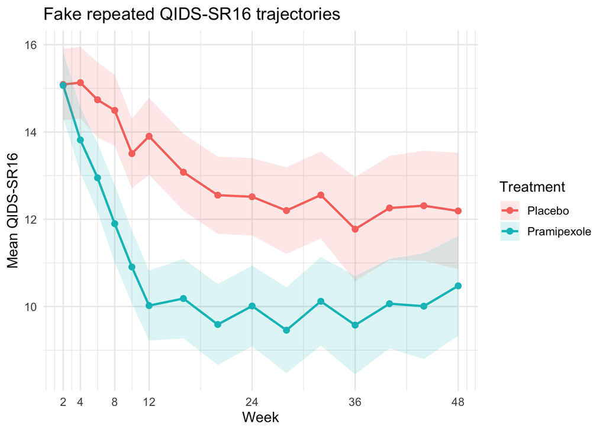

```r
plot_df <- analysis_df |>
  group_by(treatment, week) |>
  summarise(
    mean_qids = mean(qids),
    se = sd(qids) / sqrt(n()),
    .groups = "drop"
  )

ggplot(plot_df, aes(x = week, y = mean_qids, colour = treatment)) +
  geom_line(linewidth = 0.9) +
  geom_point(size = 2) +
  geom_ribbon(
    aes(ymin = mean_qids - 1.96 * se, ymax = mean_qids + 1.96 * se, fill = treatment),
    alpha = 0.15,
    colour = NA
  ) +
  scale_x_continuous(breaks = c(2, 4, 8, 12, 24, 36, 48)) +
  labs(
    title = "Fake repeated QIDS-SR16 trajectories",
    x = "Week",
    y = "Mean QIDS-SR16",
    colour = "Treatment",
    fill = "Treatment"
  ) +
  theme_minimal(base_size = 12)
```

## 10. Short interpretation

This is what the simulated output is intended to show:

- the two groups are reasonably balanced at baseline
- the pramipexole arm shows a larger improvement by week 12
- the difference narrows by week 48
- the mixed model recovers an adjusted treatment contrast at week 12 that is plausibly in the direction of the published paper

Again, this is only a **didactic fake-data exercise** built to resemble the article, not a reconstruction of the real data.